# Supervised Machine Learning on Secondary School Performance

### STAT 527 - Jingbo Liu - Fall 2021

### Author: Gabe Taylor

### Agenda

# Data Description

[figure not shown]

|  | school | sex | age | address | famsize | Pstatus | Medu | Fedu | Mjob | Fjob | ... | famrel | freetime | goout | Dalc | Walc | health | absences | G1 | G2 | G3 |
| --- | --- | --- | --- | --- | --- | --- | --- | --- | --- | --- | --- | --- | --- | --- | --- | --- | --- | --- | --- | --- | --- |
| 0 | GP | F | 18 | U | GT3 | A | 4 | 4 | at_home | teacher | ... | 4 | 3 | 4 | 1 | 1 | 3 | 6 | 5 | 6 | 6 |
| 1 | GP | F | 17 | U | GT3 | T | 1 | 1 | at_home | other | ... | 5 | 3 | 3 | 1 | 1 | 3 | 4 | 5 | 5 | 6 |
| 2 | GP | F | 15 | U | LE3 | T | 1 | 1 | at_home | other | ... | 4 | 3 | 2 | 2 | 3 | 3 | 10 | 7 | 8 | 10 |
| 3 | GP | F | 15 | U | GT3 | T | 4 | 2 | health | services | ... | 3 | 2 | 2 | 1 | 1 | 5 | 2 | 15 | 14 | 15 |
| 4 | GP | F | 16 | U | GT3 | T | 3 | 3 | other | other | ... | 4 | 3 | 2 | 1 | 2 | 5 | 4 | 6 | 10 | 10 |

5 rows × 33 columns

# EDA

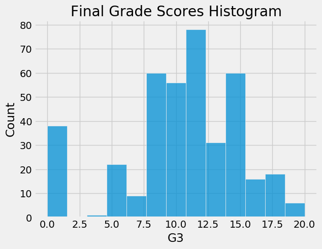

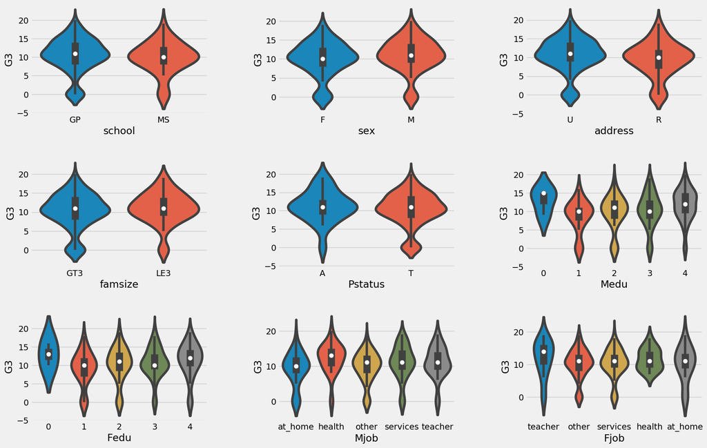

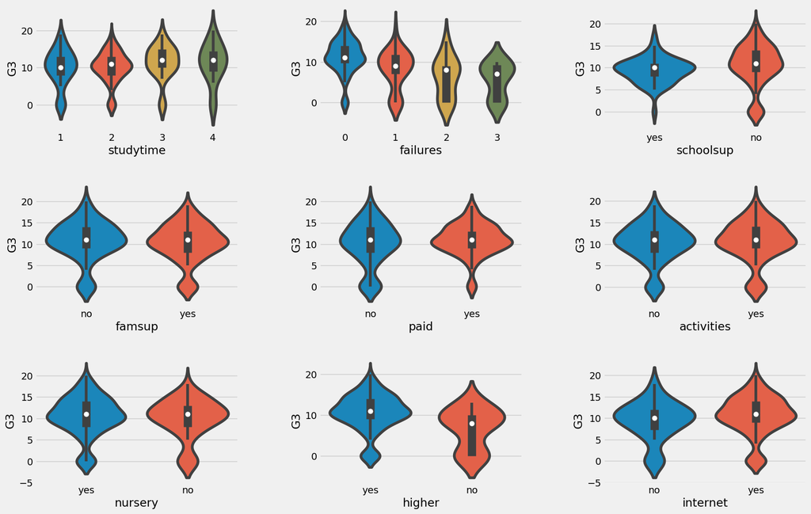

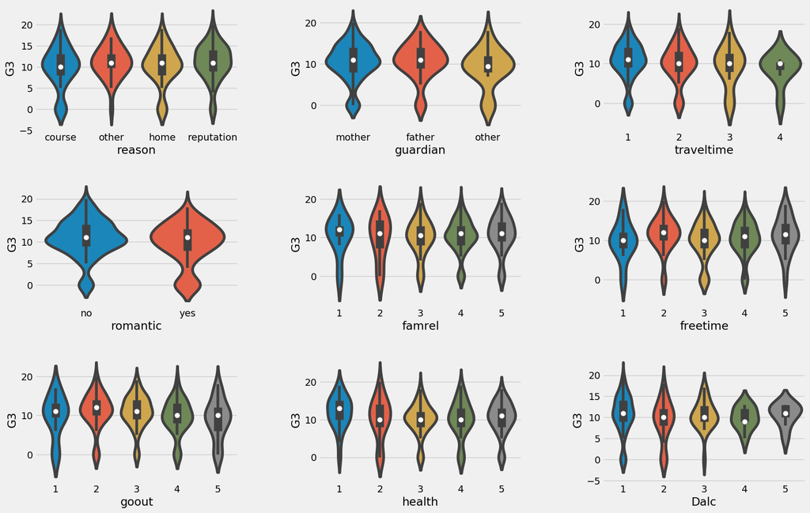

# Data PreProcessing

|  | school_MS | sex_M | address_U | famsize_LE3 | Pstatus_T | Medu_1 | Medu_2 | Medu_3 | Medu_4 | Fedu_1 | ... | Dalc_4 | Dalc_5 | Walc_2 | Walc_3 | Walc_4 | Walc_5 | health_2 | health_3 | health_4 | health_5 |
| --- | --- | --- | --- | --- | --- | --- | --- | --- | --- | --- | --- | --- | --- | --- | --- | --- | --- | --- | --- | --- | --- |
| 0 | 0 | 0 | 1 | 0 | 0 | 0 | 0 | 0 | 1 | 0 | ... | 0 | 0 | 0 | 0 | 0 | 0 | 0 | 1 | 0 | 0 |
| 1 | 0 | 0 | 1 | 0 | 1 | 1 | 0 | 0 | 0 | 1 | ... | 0 | 0 | 0 | 0 | 0 | 0 | 0 | 1 | 0 | 0 |
| 2 | 0 | 0 | 1 | 1 | 1 | 1 | 0 | 0 | 0 | 1 | ... | 0 | 0 | 0 | 1 | 0 | 0 | 0 | 1 | 0 | 0 |
| 3 | 0 | 0 | 1 | 0 | 1 | 0 | 0 | 0 | 1 | 0 | ... | 0 | 0 | 0 | 0 | 0 | 0 | 0 | 0 | 0 | 1 |
| 4 | 0 | 0 | 1 | 0 | 1 | 0 | 0 | 1 | 0 | 0 | ... | 0 | 0 | 1 | 0 | 0 | 0 | 0 | 0 | 0 | 1 |
| ... | ... | ... | ... | ... | ... | ... | ... | ... | ... | ... | ... | ... | ... | ... | ... | ... | ... | ... | ... | ... | ... |
| 390 | 1 | 1 | 1 | 1 | 0 | 0 | 1 | 0 | 0 | 0 | ... | 1 | 0 | 0 | 0 | 0 | 1 | 0 | 0 | 1 | 0 |
| 391 | 1 | 1 | 1 | 1 | 1 | 0 | 0 | 1 | 0 | 1 | ... | 0 | 0 | 0 | 0 | 1 | 0 | 1 | 0 | 0 | 0 |
| 392 | 1 | 1 | 0 | 0 | 1 | 1 | 0 | 0 | 0 | 1 | ... | 0 | 0 | 0 | 1 | 0 | 0 | 0 | 1 | 0 | 0 |
| 393 | 1 | 1 | 0 | 1 | 1 | 0 | 0 | 1 | 0 | 0 | ... | 0 | 0 | 0 | 0 | 1 | 0 | 0 | 0 | 0 | 1 |
| 394 | 1 | 1 | 1 | 1 | 1 | 1 | 0 | 0 | 0 | 1 | ... | 0 | 0 | 0 | 1 | 0 | 0 | 0 | 0 | 0 | 1 |

395 rows × 67 columns

|  | school_MS | sex_M | address_U | famsize_LE3 | Pstatus_T | Medu_1 | Medu_2 | Medu_3 | Medu_4 | Fedu_1 | ... | Walc_3 | Walc_4 | Walc_5 | health_2 | health_3 | health_4 | health_5 | age | absences | G3 |
| --- | --- | --- | --- | --- | --- | --- | --- | --- | --- | --- | --- | --- | --- | --- | --- | --- | --- | --- | --- | --- | --- |
| 0 | 0 | 0 | 1 | 0 | 0 | 0 | 0 | 0 | 1 | 0 | ... | 0 | 0 | 0 | 0 | 1 | 0 | 0 | 18 | 6 | 6 |
| 1 | 0 | 0 | 1 | 0 | 1 | 1 | 0 | 0 | 0 | 1 | ... | 0 | 0 | 0 | 0 | 1 | 0 | 0 | 17 | 4 | 6 |
| 2 | 0 | 0 | 1 | 1 | 1 | 1 | 0 | 0 | 0 | 1 | ... | 1 | 0 | 0 | 0 | 1 | 0 | 0 | 15 | 10 | 10 |
| 3 | 0 | 0 | 1 | 0 | 1 | 0 | 0 | 0 | 1 | 0 | ... | 0 | 0 | 0 | 0 | 0 | 0 | 1 | 15 | 2 | 15 |
| 4 | 0 | 0 | 1 | 0 | 1 | 0 | 0 | 1 | 0 | 0 | ... | 0 | 0 | 0 | 0 | 0 | 0 | 1 | 16 | 4 | 10 |
| ... | ... | ... | ... | ... | ... | ... | ... | ... | ... | ... | ... | ... | ... | ... | ... | ... | ... | ... | ... | ... | ... |
| 390 | 1 | 1 | 1 | 1 | 0 | 0 | 1 | 0 | 0 | 0 | ... | 0 | 0 | 1 | 0 | 0 | 1 | 0 | 20 | 11 | 9 |
| 391 | 1 | 1 | 1 | 1 | 1 | 0 | 0 | 1 | 0 | 1 | ... | 0 | 1 | 0 | 1 | 0 | 0 | 0 | 17 | 3 | 16 |
| 392 | 1 | 1 | 0 | 0 | 1 | 1 | 0 | 0 | 0 | 1 | ... | 1 | 0 | 0 | 0 | 1 | 0 | 0 | 21 | 3 | 7 |
| 393 | 1 | 1 | 0 | 1 | 1 | 0 | 0 | 1 | 0 | 0 | ... | 0 | 1 | 0 | 0 | 0 | 0 | 1 | 18 | 0 | 10 |
| 394 | 1 | 1 | 1 | 1 | 1 | 1 | 0 | 0 | 0 | 1 | ... | 1 | 0 | 0 | 0 | 0 | 0 | 1 | 19 | 5 | 9 |

395 rows × 70 columns

# Mean Model

$$RMSE = \sqrt{\frac{1}{n} \sum_{i = 1}^n (y_i - \hat y_i)^2}$$

```
Mean Model RMSE: 4.576
```

# Cross-Validation

[figure not shown]

### How to evaluate performance

One could take the average error over all of the folds:

[figure not shown]

Alternatively, one could append the cross-validation predictions to the original training data, and score the predictions using the the full training observations

[figure not shown]

### What about the Test Data?

In practice, it is useful to score the final model on a holdout set in order to evaluate how well the the model will generalize to unseen data. In the project, due to the small training size, we will not reserve a portion of the data for a hold out, but instead, we will construct a 'test set' using the 10 folds as illustrated in the second method in previous slide.

- This is how the original paper scored their models
- This is how H2o obtains cross-validation metrics

# OLS Model

### Summary

```
Training RMSE: 3.672
Cross Validation RMSE: 4.617
```

[output not shown]

70 rows × 2 columns

# LASSO Model

### Summary

```
Training RMSE: 4.086
Cross Validation RMSE: 4.362
```

### Coefficients

|  | names | standardized_coefficients |
| --- | --- | --- |
| 0 | Intercept | 10.415190 |
| 1 | school_MS | 0.000000 |
| 2 | sex_M | 0.193052 |
| 3 | address_U | 0.034271 |
| 4 | famsize_LE3 | 0.072247 |
| ... | ... | ... |
| 65 | health_3 | 0.000000 |
| 66 | health_4 | 0.000000 |
| 67 | health_5 | 0.000000 |
| 68 | age | -0.064371 |
| 69 | absences | 0.007380 |

70 rows × 2 columns

[output not shown]

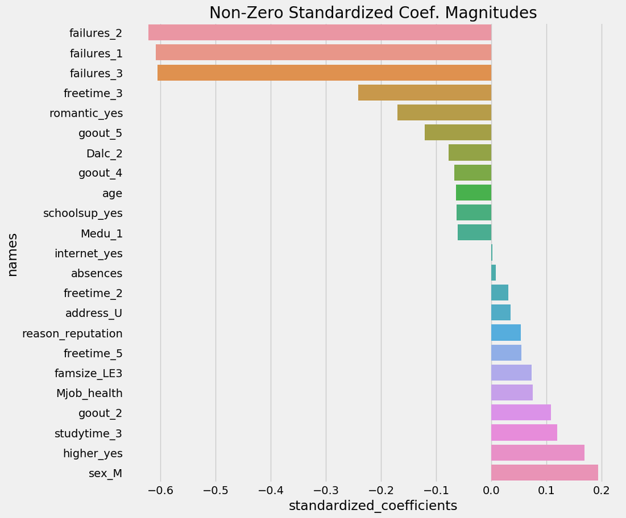

# Lambda Search

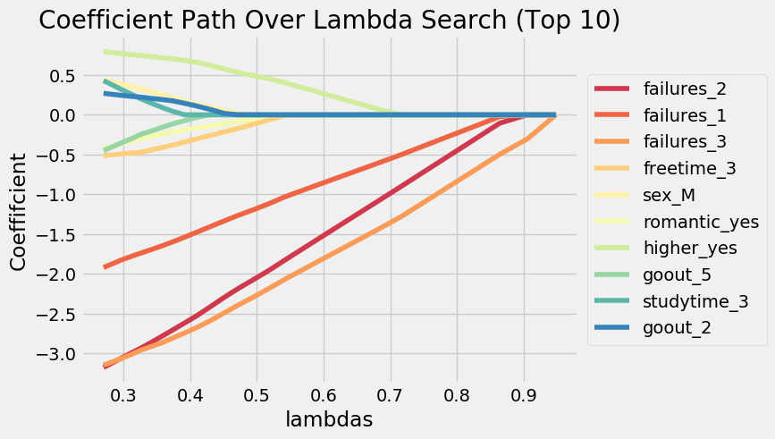

# Gradient Boosting Machines

### Decision Tree Primer

[figure not shown]

[source](https://bradleyboehmke.github.io/HOML/DT.html)

[figure not shown]

[source](https://bradleyboehmke.github.io/HOML/DT.html)

# How to fit Regression Tree?

$$f(x) = \sum_{m=1}^M c_m I(x \in r_m)$$

### Simple task if objective function is sum of squares

$$\hat c_m = \text{ave} (y_i | x_i \in R_m)$$

$$R_1(j, s) = {X|X_j \leq s} \quad \text{and} \quad R_2(j, s) = {X|X_j > s}$$

$$\min_{j, s} \left[ \min_{c_1} \sum_{x_i \in R_1(j, s)} (y_i - c_1)^2 + \min_{c_2} \sum_{x_i \in R_1(j, s)} (y_i - c_2)^2 \right]$$

$$\hat c_1 = \text{ave}(y_i |x_i \in R_1(j, s)) \quad \text{and} \quad \hat c_2 = \text{ave}(y_i |x_i \in R_2(j, s))$$

# Boosting

### How to boost decision trees

Sequentially fitting additive decision trees to the residuals of the current model.

1. Fit initial decision tree original data $T_1(x)$
2. Fit new decision tree to residuals from first tree $h_1(x) = T_1(x) - y$
3. Add new tree to global model $T_2(x) = T_1(x) + h_1(x)$
4. Fit new decision tree to residuals from second tree $h_2(x) = T_2(x) - y$
5. Add new tree to global model $T_3(x) = T_2(x) + h_2(x)$
6. Continue for some fixed number of iterations for other stopping criterion

[figure not shown]

[output not shown]

[output not shown]

```
gbm Model Build progress: |██████████████████████████████████████████████████████| (done) 100%
Model Details
=============
H2OGradientBoostingEstimator :  Gradient Boosting Machine
Model Key:  GBM_model_python_1636749588785_18


Model Summary:
```

|  |  | number_of_trees | number_of_internal_trees | model_size_in_bytes | min_depth | max_depth | mean_depth | min_leaves | max_leaves | mean_leaves |
| --- | --- | --- | --- | --- | --- | --- | --- | --- | --- | --- |
| 0 |  | 50.0 | 50.0 | 14911.0 | 5.0 | 5.0 | 5.0 | 10.0 | 25.0 | 19.06 |

```
ModelMetricsRegression: gbm
** Reported on train data. **

MSE: 0.5455371493087976
RMSE: 0.7386048668325965
MAE: 0.48501767997594575
RMSLE: 0.23759981122599827
Mean Residual Deviance: 0.5455371493087976

ModelMetricsRegression: gbm
** Reported on cross-validation data. **

MSE: 2.6290264739640623
RMSE: 1.6214272953062256
MAE: 1.0287924459711113
RMSLE: NaN
Mean Residual Deviance: 2.6290264739640623

Cross-Validation Metrics Summary:
```

|  |  | mean | sd | cv_1_valid | cv_2_valid | cv_3_valid | cv_4_valid | cv_5_valid |
| --- | --- | --- | --- | --- | --- | --- | --- | --- |
| 0 | mae | 1.026640 | 0.073279 | 0.980368 | 0.988976 | 1.121257 | 0.954555 | 1.088045 |
| 1 | mean_residual_deviance | 2.600349 | 0.521785 | 1.776238 | 3.058727 | 3.036629 | 2.506174 | 2.623979 |
| 2 | mse | 2.600349 | 0.521785 | 1.776238 | 3.058727 | 3.036629 | 2.506174 | 2.623979 |
| 3 | r2 | 0.870000 | 0.044851 | 0.920941 | 0.800252 | 0.870097 | 0.865010 | 0.893699 |
| 4 | residual_deviance | 2.600349 | 0.521785 | 1.776238 | 3.058727 | 3.036629 | 2.506174 | 2.623979 |
| 5 | rmse | 1.605446 | 0.169161 | 1.332756 | 1.748922 | 1.742593 | 1.583090 | 1.619870 |
| 6 | rmsle | 0.378733 | 0.071892 | 0.321553 | 0.328708 | 0.476983 | 0.387687 | NaN |

```
Scoring History:
```

|  |  | timestamp | duration | number_of_trees | training_rmse | training_mae | training_deviance |
| --- | --- | --- | --- | --- | --- | --- | --- |
| 0 |  | 2021-11-16 12:21:19 | 0.271 sec | 0.0 | 4.575640 | 3.428989 | 20.936478 |
| 1 |  | 2021-11-16 12:21:19 | 0.274 sec | 1.0 | 4.167054 | 3.105666 | 17.364336 |
| 2 |  | 2021-11-16 12:21:19 | 0.276 sec | 2.0 | 3.796168 | 2.813024 | 14.410891 |
| 3 |  | 2021-11-16 12:21:19 | 0.278 sec | 3.0 | 3.466612 | 2.558943 | 12.017397 |
| 4 |  | 2021-11-16 12:21:19 | 0.280 sec | 4.0 | 3.174204 | 2.338405 | 10.075568 |
| 5 |  | 2021-11-16 12:21:19 | 0.281 sec | 5.0 | 2.913417 | 2.146553 | 8.487997 |
| 6 |  | 2021-11-16 12:21:19 | 0.283 sec | 6.0 | 2.681236 | 1.976713 | 7.189029 |
| 7 |  | 2021-11-16 12:21:19 | 0.284 sec | 7.0 | 2.473818 | 1.827916 | 6.119776 |
| 8 |  | 2021-11-16 12:21:19 | 0.286 sec | 8.0 | 2.292323 | 1.692708 | 5.254743 |
| 9 |  | 2021-11-16 12:21:19 | 0.288 sec | 9.0 | 2.126083 | 1.571902 | 4.520227 |
| 10 |  | 2021-11-16 12:21:19 | 0.289 sec | 10.0 | 1.983918 | 1.463144 | 3.935931 |
| 11 |  | 2021-11-16 12:21:19 | 0.291 sec | 11.0 | 1.861494 | 1.368957 | 3.465161 |
| 12 |  | 2021-11-16 12:21:19 | 0.292 sec | 12.0 | 1.753742 | 1.283198 | 3.075610 |
| 13 |  | 2021-11-16 12:21:19 | 0.293 sec | 13.0 | 1.649434 | 1.202136 | 2.720634 |
| 14 |  | 2021-11-16 12:21:19 | 0.295 sec | 14.0 | 1.565453 | 1.135448 | 2.450642 |
| 15 |  | 2021-11-16 12:21:19 | 0.297 sec | 15.0 | 1.497102 | 1.075200 | 2.241314 |
| 16 |  | 2021-11-16 12:21:19 | 0.298 sec | 16.0 | 1.427987 | 1.022821 | 2.039147 |
| 17 |  | 2021-11-16 12:21:19 | 0.300 sec | 17.0 | 1.369021 | 0.972751 | 1.874220 |
| 18 |  | 2021-11-16 12:21:19 | 0.301 sec | 18.0 | 1.319878 | 0.931341 | 1.742078 |
| 19 |  | 2021-11-16 12:21:19 | 0.303 sec | 19.0 | 1.272346 | 0.889428 | 1.618865 |

```
See the whole table with table.as_data_frame()

Variable Importances:
```

|  | variable | relative_importance | scaled_importance | percentage |
| --- | --- | --- | --- | --- |
| 0 | G2 | 32841.832031 | 1.000000 | 0.774723 |
| 1 | absences | 5931.299805 | 0.180602 | 0.139917 |
| 2 | age | 934.687805 | 0.028460 | 0.022049 |
| 3 | reason | 494.909943 | 0.015069 | 0.011675 |
| 4 | G1 | 312.668243 | 0.009520 | 0.007376 |
| 5 | Fjob | 237.929459 | 0.007245 | 0.005613 |
| 6 | guardian | 224.171295 | 0.006826 | 0.005288 |
| 7 | famrel | 210.839600 | 0.006420 | 0.004974 |
| 8 | activities | 170.276077 | 0.005185 | 0.004017 |
| 9 | health | 169.944199 | 0.005175 | 0.004009 |
| 10 | goout | 139.535873 | 0.004249 | 0.003292 |
| 11 | Mjob | 136.203491 | 0.004147 | 0.003213 |
| 12 | studytime | 115.187965 | 0.003507 | 0.002717 |
| 13 | traveltime | 114.101830 | 0.003474 | 0.002692 |
| 14 | Walc | 103.469376 | 0.003151 | 0.002441 |
| 15 | freetime | 60.049408 | 0.001828 | 0.001417 |
| 16 | Fedu | 51.092613 | 0.001556 | 0.001205 |
| 17 | Medu | 36.198334 | 0.001102 | 0.000854 |
| 18 | failures | 35.389370 | 0.001078 | 0.000835 |
| 19 | romantic | 19.636011 | 0.000598 | 0.000463 |

```
See the whole table with table.as_data_frame()
```